# R Tutorial 002: ggplot2

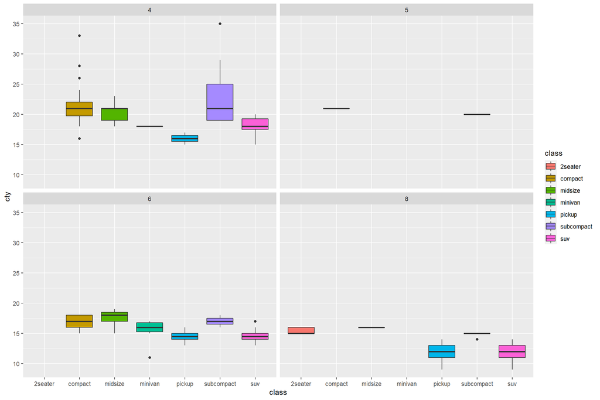

```r
ggplot(mpg) +
  geom_boxplot(aes(x = class, y = cty, fill = class)) +
  facet_wrap(facets = ~cyl, nrow = 2, ncol = 2)
```

Other coordinate systems can be applied to graphs created from ggplot2. One example is `coord_polar()`, which uses polar coordinates. Most of these are quite rare. Probably the most common one is `coord_flip()`, which will flip the X and Y axes. Let’s also illustrate the `labs()` function, which can be used to change labels.

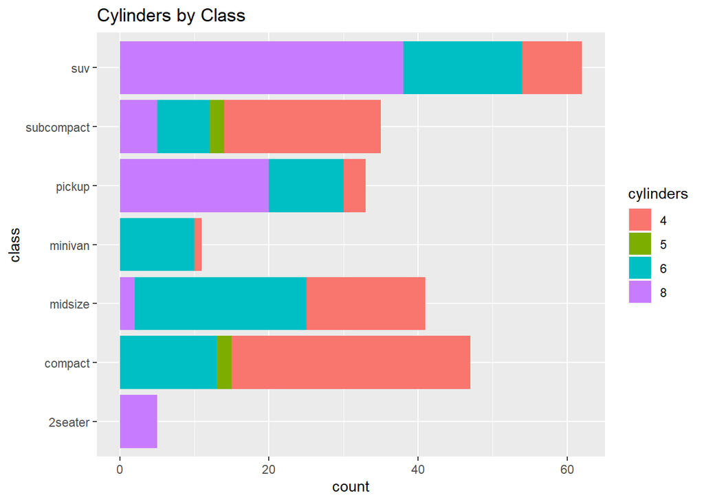

```r
ggplot(mpg) +
  geom_bar(aes(x = class, fill = factor(cyl))) +
  labs(title = "Cylinders by Class", fill = "cylinders") +
  coord_flip()
```

These bars are stacked on top of each of other, due to the “cyl” variable being mapped to the “fill” argument. There are various position adjustments that can be used. Again, most of these are not very common, but a common one is the argument “position = ‘dodge’”, which will put items side-by-side. See this example:

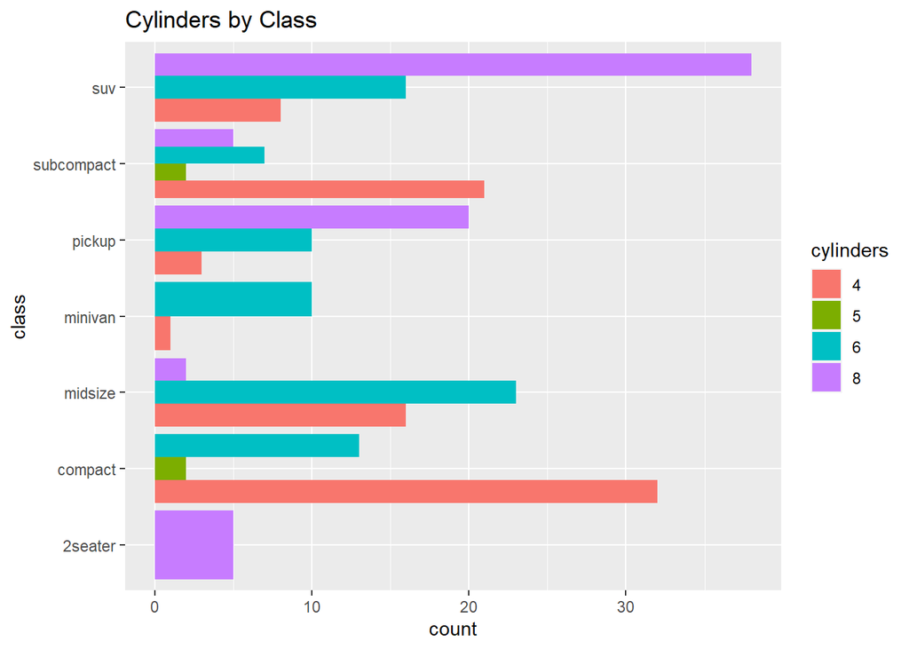

```r
ggplot(mpg) +
  geom_bar(aes(x = class, fill = factor(cyl)), position = "dodge") +
  labs(title = "Cylinders by Class", fill = "cylinders") +
  coord_flip()
```

Lastly, we can alter the “theme”, or the overall appearance of our plot. I recommend using the ggThemeAssist package, because this will make this incredibly easy, with an interface that will automatically generate reproducible code. This can be used by highlighting a ggplot2 object, and navigating to Addins > ggplot Theme Assistant. We’ll make the following changes: eliminating the panel grid lines, eliminating axis ticks, adding a title called “Boxplot Example”, making it bigger and putting it in bold, and adjusting it to the center.

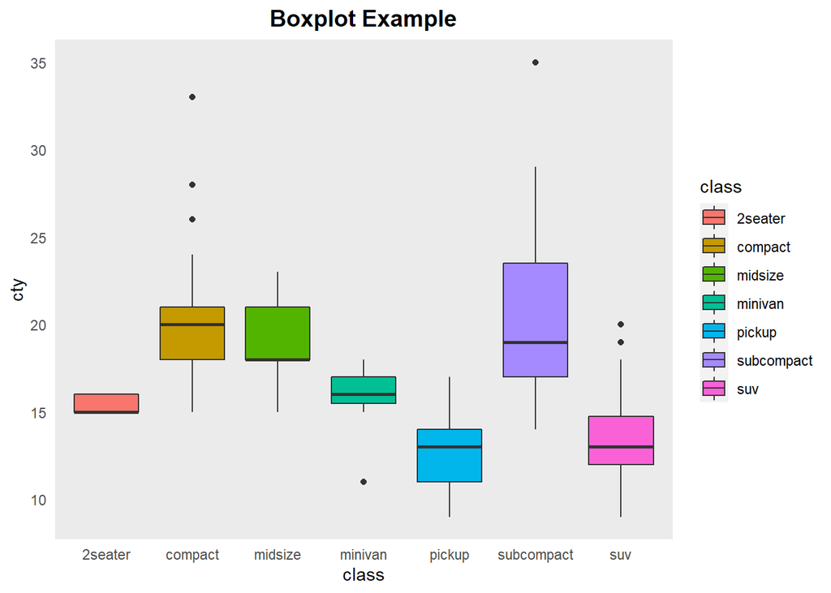

```r
# p

p + theme(axis.ticks = element_line(linetype = "blank"),
    panel.grid.major = element_line(linetype = "blank"),
    panel.grid.minor = element_line(linetype = "blank"),
    plot.title = element_text(size = 14,
        face = "bold", hjust = 0.5)) +labs(title = "Boxplot Example")
```

There are many more examples of things that can be done with ggplot2. It is an amazingly powerful and flexible package, and it is worth getting acquainted with the cheat sheet.